# Seaborn Examples

## Setup

### Installation

First step is t install the `seaborn` package. For that, we can use `pip` as

```python
%pip install seaborn
```

### Imports

To get started with `seaborn` we need to import the following packages. We import `pyplot` form `matplotlib` to use the lower level APIs later for styling and customization. While working with Jupyter notebooks we might want to suppers warnings in the output.

```python
import numpy as np
import seaborn as sns
import matplotlib.pyplot as plt
import warnings
```

### Jupyter Configurations

Ask Jupyter to display plots within the notebook

```python
%matplotlib inline
%reload_ext autoreload
%autoreload 2
```

Suppress warnings

```python
import warnings
warnings.filterwarnings('ignore')
```

### Data

Plotting only makes sense if we have some data to visualize. We can plot any data stored in pandas data structure using `seaborn`. This let's us load and process data using pandas and use `seaborn` for visualization in parallel. For this post, I'll make use of sample datasets shipped with `seaborn`. To get the full list of datasets available in our installation we can as `seaborn` itself

```python
print(sns.get_dataset_names())
```

```
['anagrams', 'anscombe', 'attention', 'brain_networks', 'car_crashes', 'diamonds', 'dots', 'dowjones', 'exercise', 'flights', 'fmri', 'geyser', 'glue', 'healthexp', 'iris', 'mpg', 'penguins', 'planets', 'seaice', 'taxis', 'tips', 'titanic']
```

Let's load two datasets and examine their content. More information on the datasets can be found [here](https://medium.com/r/?url=https%3A%2F%2Fwww.kaggle.com%2Fdatasets%2Ffivethirtyeight%2Ffivethirtyeight-bad-drivers-dataset) and [here](https://medium.com/r/?url=https%3A%2F%2Fwww.kaggle.com%2Fc%2Ftitanic%2Fdata)

```python
crashes = sns.load_dataset('car_crashes')
titanic = sns.load_dataset('titanic')
```

Examine the content of the data

```python
crashes.head()
```

|  | total | speeding | alcohol | not_distracted | no_previous | ins_premium | ins_losses | abbrev |
| --- | --- | --- | --- | --- | --- | --- | --- | --- |
| 0 | 18.8 | 7.332 | 5.640 | 18.048 | 15.040 | 784.55 | 145.08 | AL |
| 1 | 18.1 | 7.421 | 4.525 | 16.290 | 17.014 | 1053.48 | 133.93 | AK |
| 2 | 18.6 | 6.510 | 5.208 | 15.624 | 17.856 | 899.47 | 110.35 | AZ |
| 3 | 22.4 | 4.032 | 5.824 | 21.056 | 21.280 | 827.34 | 142.39 | AR |
| 4 | 12.0 | 4.200 | 3.360 | 10.920 | 10.680 | 878.41 | 165.63 | CA |

```python
titanic.head()
```

|  | survived | pclass | sex | age | sibsp | parch | fare | embarked | class | who | adult_male | deck | embark_town | alive | alone |
| --- | --- | --- | --- | --- | --- | --- | --- | --- | --- | --- | --- | --- | --- | --- | --- |
| 0 | 0 | 3 | male | 22.0 | 1 | 0 | 7.2500 | S | Third | man | True | NaN | Southampton | no | False |
| 1 | 1 | 1 | female | 38.0 | 1 | 0 | 71.2833 | C | First | woman | False | C | Cherbourg | yes | False |
| 2 | 1 | 3 | female | 26.0 | 0 | 0 | 7.9250 | S | Third | woman | False | NaN | Southampton | yes | True |
| 3 | 1 | 1 | female | 35.0 | 1 | 0 | 53.1000 | S | First | woman | False | C | Southampton | yes | False |
| 4 | 0 | 3 | male | 35.0 | 0 | 0 | 8.0500 | S | Third | man | True | NaN | Southampton | no | True |

## Categorical Data

Categorical data is form of qualitative data that can be stored and identified based on distinct labels. Instead of being measured numerically, it is a type of information that can be grouped into categories. For example, the sex column in our titanic dataset has two labels: male and female. Similarly the abbrev column is a list of state name abbreviations in the US which has a total of 50 labels. In this section, we will see bar and count plots from `seaborn` as two graphics to visualize categorical data.  
In this section, we will see bar and count plots from `seaborn` as two graphics to visualize categorical data.

### Bar Plots

Also referred to as `bar chart`, bar plot is, a bar plot allows us to visualize the comparisons between the discrete labels or categories in our data. Bar chart is a graph that represents the category of data with horizontally or vertically rectangular bars with lengths and heights that is proportional to the values which they represent. One of the axis of the plot represents the specific categories being compared, while the other axis represents the measured values corresponding to those categories.

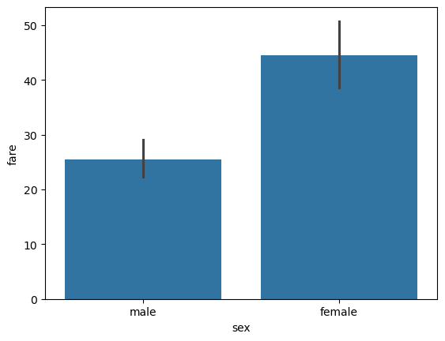

```python
sns.barplot(data = titanic, x = 'sex', y='fare')
```

By Default the data is aggregated by mean of `y`

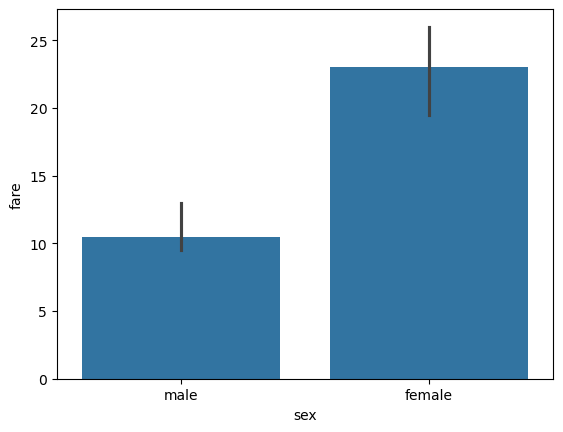

```python
sns.barplot(data = titanic, x = 'sex', y='fare', estimator=np.median)
```

### Count Plots

Similar to bar plot but uses count as the estimator

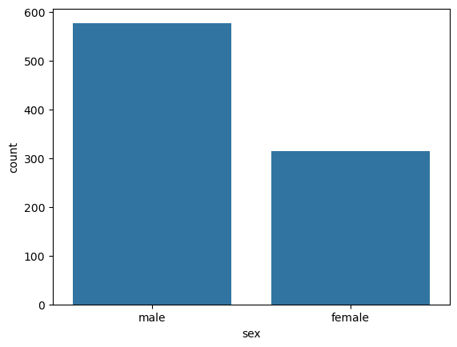

```python
sns.countplot(data = titanic, x = 'sex')
```

We can display a count of the number rows in each category of values in the alive column

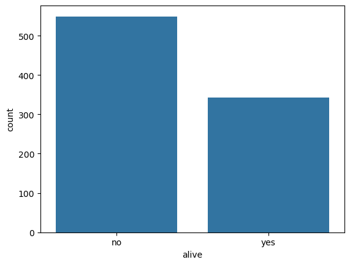

```python
sns.countplot(data = titanic, x = 'alive')
```

## Distribution Plots

Distribution plots for continuous data variables.In the past, `Seaborn` had a `distplot` method which supported displaying a histogram plot by with kde on top default. `distplot` is deprecated and it is recommended we use `displot` or `histplot` for find grained control. `distplot` allow as to display a histogram of univariate or bivariate distribution of the data in a dataset.

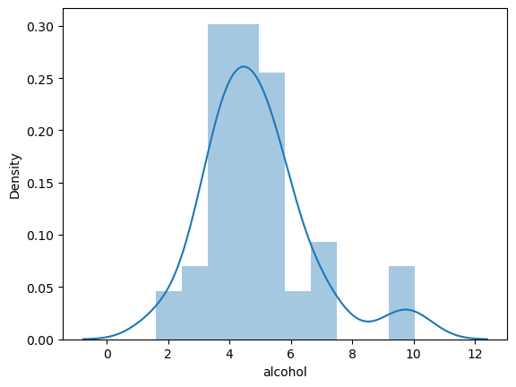

```python
sns.distplot(a=crashes['alcohol'])
```

If we don't what the kde plot to be visible we can tell seaborn not to show it

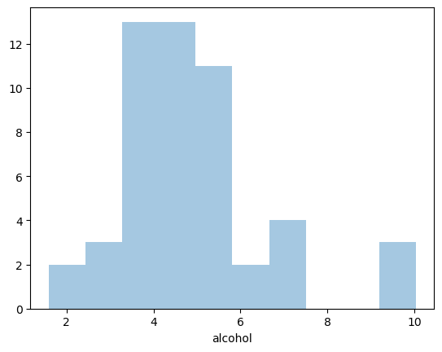

```python
sns.distplot(a=crashes['alcohol'],kde=False)
```

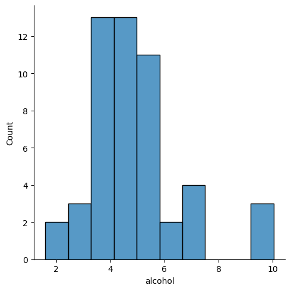

```python
sns.displot(data=crashes['alcohol'])
```

The equivalent plot can be displayed using the new `displot` method

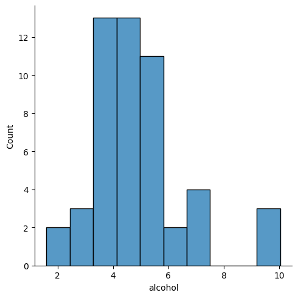

```python
# We can specify name of the data column in the dataset if there are more than one
sns.displot(data=crashes, x='alcohol')
```

`displot` combines a histogram with optional components, such as a Kernel Density Estimation (KDE) line or rug plot. We can specify which type we want to plot using the kind key (default is hist)

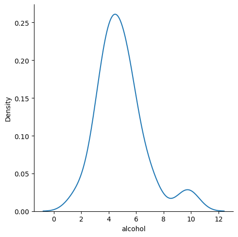

```python
sns.displot(data=crashes['alcohol'], kind='kde')
```

We can enable an overlay of other visualization on top of the default. We can do this by passing a boolean value for the parameters `hist`, `ecdf`, `kde`, `rug`

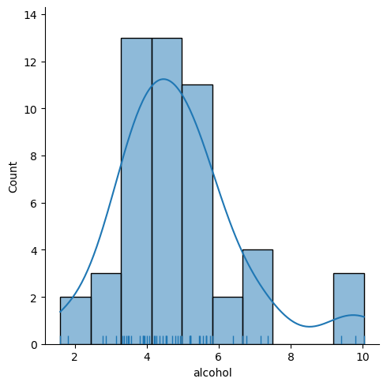

```python
sns.displot(data=crashes['alcohol'], kde=True, rug=True)
```

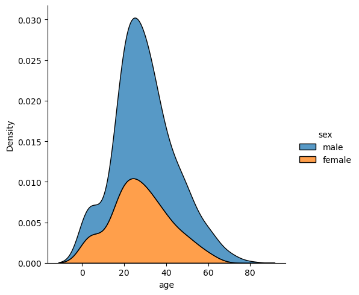

```python
sns.displot(data=titanic, x='age', hue='sex', kind='kde', multiple='stack')
```

### KDE Plot

We can display kde plots using the `kdeplot` function as well

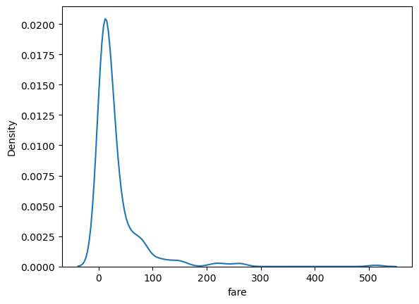

```python
sns.kdeplot(data=titanic, x='fare')
```

## Categorical Plots

### Box Plot

Compare different variables

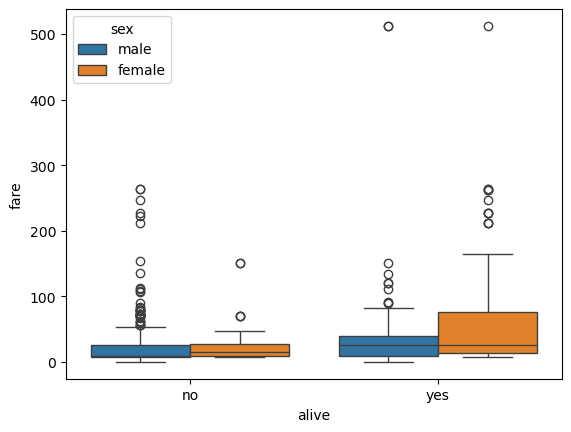

```python
sns.boxplot(data = titanic, x = 'alive', y='fare', hue='sex')
```

### Violin Plot

Compare different variables in a different visualization

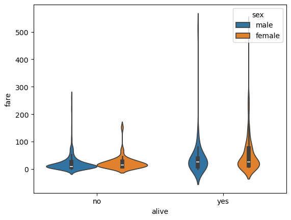

```python
sns.violinplot(data = titanic, x = 'alive', y='fare', hue='sex')
```

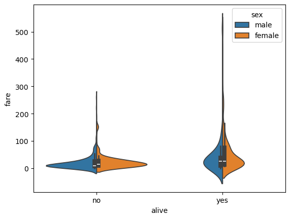

```python
sns.violinplot(data = titanic, x = 'alive', y='fare', hue='sex', split=True)
```

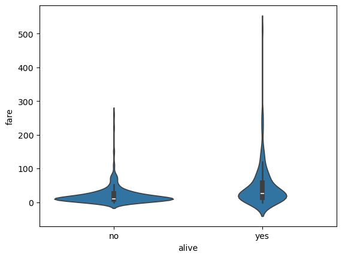

```python
#survived	pclass	sex	age	sibsp	parch	fare	embarked	class	who	adult_male	deck	embark_town	alive	alone
sns.violinplot(data = titanic, x = 'alive', y='fare')
```

### Strip Plot

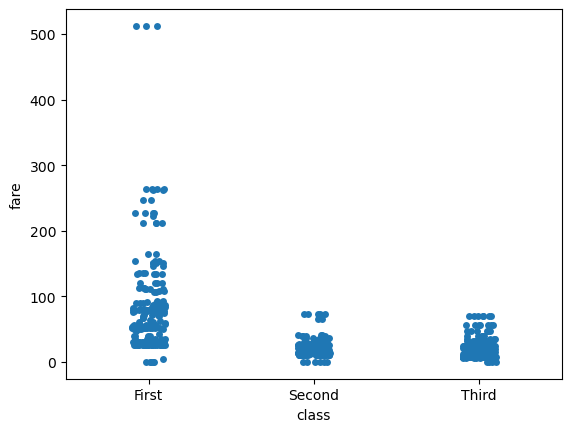

```python
sns.stripplot(data = titanic, x = 'class', y='fare')
```

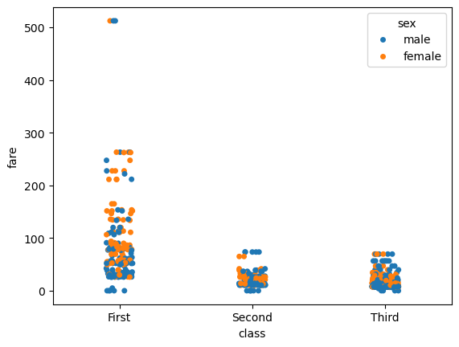

```python
sns.stripplot(data = titanic, x = 'class', y='fare', hue='sex')
```

### Swarm Plot

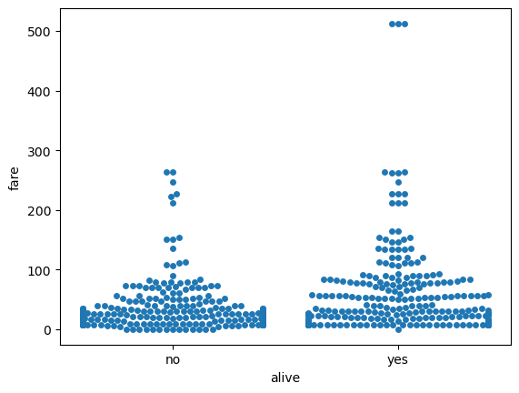

```python
sns.swarmplot(data = titanic, x = 'alive', y='fare')
```

## Comparing Data

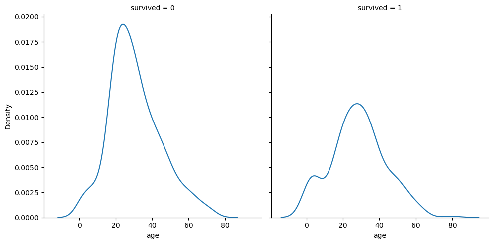

```python
sns.displot(data=titanic, x='age', col='survived',  kind='kde')
```

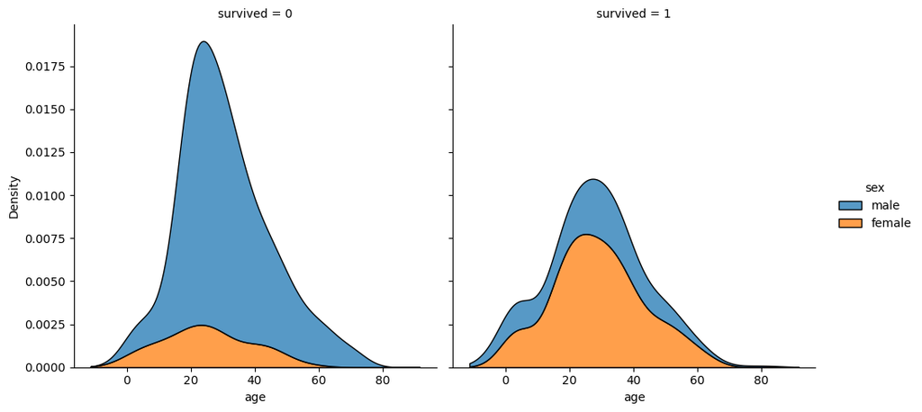

```python
sns.displot(data=titanic, x='age', col='survived', hue='sex', kind='kde', multiple='stack')
```

### Joint Plot

Used for comparing two distributions. By default it uses scatter plot

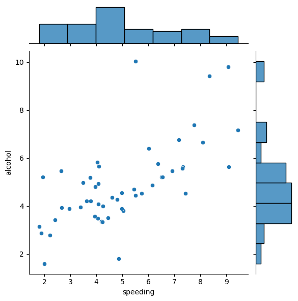

```python
sns.jointplot(data=crashes, x='speeding',y='alcohol')
```

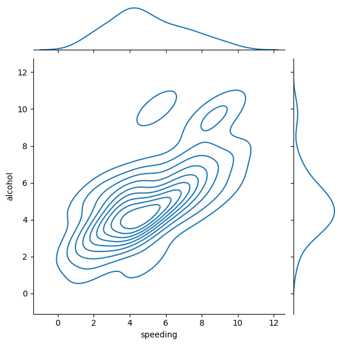

```python
sns.jointplot(data=crashes, x='speeding',y='alcohol', kind='kde')
```

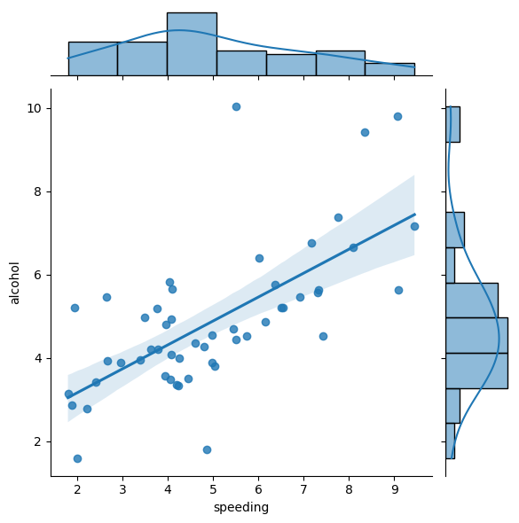

```python
sns.jointplot(data=crashes, x='speeding',y='alcohol', kind='reg')
```

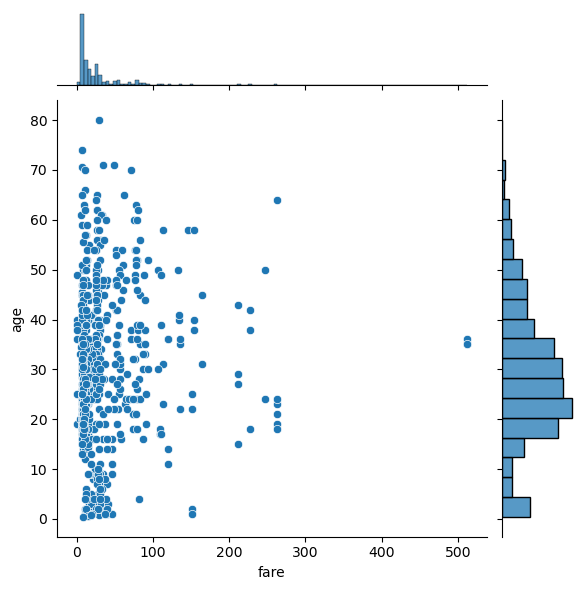

```python
sns.jointplot(data=titanic, x='fare',y='age')
```